# 01_GenArch_Figs_2016-07-12

Heather E. Wheeler

2016-07-17 13:45:13

```r
  library(ggplot2)
  library(reshape2)
  library(dplyr)
  library(tidyr)
  library(GGally)
  library(grid)
  library(corrplot)
  "%&%" = function(a,b) paste(a,b,sep="")
  source('/Volumes/im-lab/nas40t2/hwheeler/cross-tissue/GenArchPaper/multiplot.R')
  my.dir <- '/Volumes/im-lab/nas40t2/hwheeler/cross-tissue/'
  fig.dir <- '~/GitHub/GenArch/GenArchPaper/Figures/'
  my.vol <- '/Volumes/im-lab/nas40t2/hwheeler/cross-tissue/BSLMM_exp/'
  rna.dir <- my.dir %&% "gtex-rnaseq/"
  out.dir <- rna.dir %&% "ind-tissues-RPKM/"
  dgn.dir <- '/Volumes/im-lab/nas40t2/hwheeler/PrediXcan_CV/GTEx_2014-06013_release/transfers/PrediXmod/DGN-WB/DGN-calc-weights/'
  se <- function(x) sqrt(var(x,na.rm=TRUE)/length(is.na(x)==FALSE))
```

## Fig1

DGN-WB joint heritability. Local h<sup>2</sup> is estimated with SNPs within 1 Mb of each gene. distal h<sup>2</sup> is estimated with either all non-chr SNPs or SNPs that are eQTLs in the Framingham Heart Study on other chromosomes (FDR < 0.05).

```r
dgn <- read.table(my.dir %&% 'expArch_DGN-WB_imputedGTs/DGN-WB.h2.all.models_FHSfdr0.05.Chr1-22_globalAll_reml-no-constrain.2015-12-15.txt',header=T)
mean(dgn$loc.jt.h2,na.rm=TRUE)
```

```
## [1] 0.1425762
```

```r
se(dgn$loc.jt.h2)
```

```
## [1] 0.001525862
```

```r
mean(dgn$glo.jt.h2,na.rm=TRUE)
```

```
## [1] 0.03402624
```

```r
mean(dgn$global.se,na.rm=TRUE)
```

```
## [1] 0.2852095
```

```r
data <- dgn[complete.cases(dgn),]
dim(dgn)
```

```
## [1] 12719    16
```

```r
dim(data)
```

```
## [1] 9071   16
```

```r
dgn <- read.table(my.dir %&% 'expArch_DGN-WB_imputedGTs/DGN-WB.h2.all.models_FHSfdr0.05.Chr1-22_globaleQTLOtherChr_reml-no-constrain.2015-12-13.txt',header=T)
mean(dgn$loc.jt.h2,na.rm=TRUE)
```

```
## [1] 0.1326047
```

```r
se(dgn$loc.jt.h2)
```

```
## [1] 0.001470276
```

```r
mean(dgn$glo.jt.h2,na.rm=TRUE)
```

```
## [1] 0.01619451
```

```r
mean(dgn$global.se,na.rm=TRUE)
```

```
## [1] 0.1507227
```

```r
data <- dgn[complete.cases(dgn),]
dim(dgn)
```

```
## [1] 12719    16
```

```r
dim(data)
```

```
## [1] 10489    16
```

```r
##Fig1 UNCONSTRAINED
#DGN-WB joint heritability. Local h^2^ is estimated with SNPs within 1 Mb of each gene.
#distal h^2^ is estimated with either all non-chr SNPs or SNPs that are eQTLs in the Framingham Heart Study on other chromosomes (FDR < 0.05).
otherfile<-my.dir %&% 'expArch_DGN-WB_imputedGTs/DGN-WB.h2.all.models_FHSfdr0.05.Chr1-22_globaleQTLOtherChr_reml-no-constrain.2015-12-13.txt'

fdrother<-read.table(otherfile,header=T) ##FHS eQTLs w/fdr<0.05 on non-gene chromosomes used to define global GRM
d  <- fdrother %>% mutate(ymin = glo.jt.h2 - 2 * glo.jt.se, ymax = glo.jt.h2 + 2 * glo.jt.se)
#fdrother <- mutate(d, loc.jt.P = ifelse(loc.jt.h2 > 0, 2*pnorm(-abs(loc.jt.h2/loc.jt.se)),1) , glo.jt.P = ifelse(glo.jt.h2 > 0, 2*pnorm(-abs(glo.jt.h2/glo.jt.se)),1))
fdrother <- mutate(d, loc.jt.P = 2*pnorm(-abs(loc.jt.h2/loc.jt.se)) , glo.jt.P = 2*pnorm(-abs(glo.jt.h2/glo.jt.se)))
fdrother <- mutate(fdrother, loc.jt.P=ifelse(is.na(loc.jt.P),1,loc.jt.P),glo.jt.P=ifelse(is.na(glo.jt.P),1,glo.jt.P)) %>%
  mutate(locPlt05=loc.jt.P < 0.05,gloPlt05=glo.jt.P < 0.05) %>% mutate(`distal P`=factor(gloPlt05,labels=c('\u2265 0.05','< 0.05')))
table(fdrother$gloPlt05)
```

```
##
## FALSE  TRUE
## 11868   851
```

```r
##Plot FDR based results
a<-ggplot(fdrother,aes(x=loc.jt.h2,y=glo.jt.h2,color=`distal P`)) + geom_point(cex=1,alpha=2/3)  +
  xlab(expression("local h"^2)) + ylab(expression("distal h"^2)) + coord_cartesian(xlim=c(-0.05,1.05),ylim=c(-0.7,1.3)) + theme_bw() +
  theme(axis.text=element_text(size=16),axis.title=element_text(size=18,face="bold"),legend.justification=c(1,1),legend.position=c(1,1))

##plot joint h2 estimates
local <- fdrother %>% select(loc.jt.h2,loc.jt.se,loc.jt.P,locPlt05,ensid)%>% arrange(loc.jt.h2)
local <- local %>% mutate(loc.jt.h2=ifelse(is.na(loc.jt.h2),0,loc.jt.h2), loc.jt.se=ifelse(is.na(loc.jt.se),base::sample(loc.jt.se[is.na(loc.jt.se)==FALSE][1:100],size=length(loc.jt.se[is.na(loc.jt.se)==TRUE]),replace=TRUE),loc.jt.se))%>% arrange(loc.jt.h2)
names(local) = c('h2','se','jt.P','Plt05','ensid')
local <- local %>% mutate(ymin =  h2 - 2 * se, ymax =  h2 + 2 * se )
cigt0 <- local$ymin>0
table(local$jt.P < 0.05,useNA='i')
```

```
##
## FALSE  TRUE
##  5445  7274
```

```r
sum(table(local$jt.P < 0.05,useNA='i'))
```

```
## [1] 12719
```

```r
ptrue <-round(table(local$jt.P < 0.05,useNA='i')/sum(table(local$jt.P < 0.05,useNA='i')),3)*100
ptrue
```

```
##
## FALSE  TRUE
##  42.8  57.2
```

```r
meanh2<-round(mean(local$h2),3)
meanh2
```

```
## [1] 0.125
```

```r
meanse <- round(mean(local$se),3)
meanse
```

```
## [1] 0.027
```

```r
local <- mutate(local,P=factor(Plt05,labels=c("\u2265 0.05","< 0.05")),position=1:nrow(local))
my_grob2 = grobTree(textGrob(substitute(paste("% P < 0.05: ", m),list(m=ptrue[2])), x=0.05,  y=0.70, hjust=0,gp=gpar(fontsize=14)))

b<-ggplot(local,aes(x=position,y=h2,ymin=ymin, ymax=ymax, color=P) ) + geom_pointrange(col='gray')+geom_point()+ylab(expression("local h"^2)) +
  xlab(expression("genes ordered by local h"^2))+theme_bw()+
  theme(axis.text=element_text(size=16),axis.title=element_text(size=18,face="bold"),legend.justification=c(0,1),legend.position=c(0,1))+
  annotation_custom(my_grob2)

global <- fdrother %>% select(gene,glo.jt.h2,glo.jt.se,glo.jt.P,gloPlt05,ensid) %>% arrange(glo.jt.h2) %>% mutate(glo.jt.h2=ifelse(is.na(glo.jt.h2),0,glo.jt.h2), glo.jt.se=ifelse(is.na(glo.jt.se),base::sample(glo.jt.se[is.na(glo.jt.se)==FALSE][1:1000],size=length(glo.jt.se[is.na(glo.jt.se)==TRUE]),replace=TRUE),glo.jt.se))%>% arrange(glo.jt.h2)
names(global) = c('gene','h2','se','jt.P','Plt05','ensid')
global <- global %>% mutate(ymin =  h2 - 2 * se, ymax =  h2 + 2 * se)
table(global$jt.P < 0.05,useNA='i')
```

```
##
## FALSE  TRUE
## 11868   851
```

```r
sum(table(global$jt.P < 0.05,useNA='i'))
```

```
## [1] 12719
```

```r
ptrue <-signif(table(global$jt.P < 0.05,useNA='i')/sum(table(global$jt.P < 0.05,useNA='i')),3)*100
ptrue
```

```
##
## FALSE  TRUE
## 93.30  6.69
```

```r
meanh2<-round(mean(global$h2),3)
meanh2
```

```
## [1] 0.015
```

```r
meanse <- round(mean(global$se),3)
meanse
```

```
## [1] 0.136
```

```r
global <- mutate(global,P=factor(Plt05,labels=c("\u2265 0.05","< 0.05")),position=1:nrow(global))

glopriorlist <- dplyr::filter(global,Plt05==TRUE) %>% dplyr::select(gene)

my_grob2 = grobTree(textGrob(substitute(paste("% P < 0.05: ", m),list(m=ptrue[2])), x=0.05,  y=0.70, hjust=0,gp=gpar(fontsize=14)))

c<-ggplot(global,aes(x=position,y=h2,ymin=ymin, ymax=ymax, color=P) ) + geom_pointrange(col='gray')+geom_point()+ylab(expression("distal h"^2)) +
  xlab(expression("genes ordered by distal h"^2))+theme_bw()+coord_cartesian(ylim=c(-1.05,1.55))+
  theme(axis.text=element_text(size=16),axis.title=element_text(size=18,face="bold"),legend.justification=c(0,1),legend.position=c(0,1))+
  annotation_custom(my_grob2)

##make same plots using all SNPs on other chrs for global
otherfile<-my.dir %&% 'expArch_DGN-WB_imputedGTs/DGN-WB.h2.all.models_FHSfdr0.05.Chr1-22_globalAll_reml-no-constrain.2015-12-15.txt'

other<-read.table(otherfile,header=T) ##all SNPs on non-gene chromosomes used to define global GRM
d  <- other %>% mutate(ymin =  glo.jt.h2 - 2 * glo.jt.se, ymax =  glo.jt.h2 + 2 * glo.jt.se )

#other <- mutate(d, loc.jt.P = ifelse(loc.jt.h2 > 0, 2*pnorm(-abs(loc.jt.h2/loc.jt.se)),1), glo.jt.P = ifelse(glo.jt.h2 > 0, 2*pnorm(-abs(glo.jt.h2/glo.jt.se)),1)) %>% mutate(loc.jt.P=ifelse(is.na(loc.jt.P),1,loc.jt.P),glo.jt.P=ifelse(is.na(glo.jt.P),1,glo.jt.P)) %>%   mutate(locPlt05=loc.jt.P < 0.05,gloPlt05=glo.jt.P < 0.05) %>% mutate(`distal P`=factor(gloPlt05,labels=c('\u2265 0.05','< 0.05')))
other <- mutate(d, loc.jt.P = 2*pnorm(-abs(loc.jt.h2/loc.jt.se)) , glo.jt.P = 2*pnorm(-abs(glo.jt.h2/glo.jt.se))) %>% mutate(loc.jt.P=ifelse(is.na(loc.jt.P),1,loc.jt.P),glo.jt.P=ifelse(is.na(glo.jt.P),1,glo.jt.P)) %>%   mutate(locPlt05=loc.jt.P < 0.05,gloPlt05=glo.jt.P < 0.05) %>% mutate(`distal P`=factor(gloPlt05,labels=c('\u2265 0.05','< 0.05')))
table(other$gloPlt05)
```

```
##
## FALSE  TRUE
## 11788   931
```

```r
aother<-ggplot(other,aes(x=loc.jt.h2,y=glo.jt.h2,color=`distal P`)) + geom_point(cex=1,alpha=2/3) +
  xlab(expression("local h"^2)) + ylab(expression("distal h"^2)) + coord_cartesian(xlim=c(-0.05,1.05),ylim=c(-0.7,1.3)) + theme_bw() +
  theme(axis.text=element_text(size=16),axis.title=element_text(size=18,face="bold"),legend.justification=c(1,1),legend.position=c(1,1))

localall <- other %>% select(loc.jt.h2,loc.jt.se,loc.jt.P,locPlt05,ensid) %>% arrange(loc.jt.h2) %>%
  mutate(loc.jt.h2=ifelse(is.na(loc.jt.h2),0,loc.jt.h2), loc.jt.se=ifelse(is.na(loc.jt.se),
  base::sample(loc.jt.se[is.na(loc.jt.se)==FALSE][1:100],size=length(loc.jt.se[is.na(loc.jt.se)==TRUE]),replace=TRUE),loc.jt.se))%>% arrange(loc.jt.h2)
names(localall) = c('h2','se','jt.P','Plt05','ensid')
localall <- localall %>% mutate(ymin =  h2 - 2 * se, ymax =  h2 + 2 * se )
table(localall$jt.P < 0.05,useNA='i')
```

```
##
## FALSE  TRUE
##  6320  6399
```

```r
sum(table(localall$jt.P < 0.05,useNA='i'))
```

```
## [1] 12719
```

```r
ptrue <-round(table(localall$jt.P < 0.05,useNA='i')/sum(table(localall$jt.P < 0.05,useNA='i')),3)*100
ptrue
```

```
##
## FALSE  TRUE
##  49.7  50.3
```

```r
meanh2<-round(mean(localall$h2),3)
meanh2
```

```
## [1] 0.114
```

```r
meanse <- round(mean(localall$se),3)
meanse
```

```
## [1] 0.024
```

```r
localall <- mutate(localall,P=factor(Plt05,labels=c("\u2265 0.05","< 0.05")),position=1:nrow(localall))
my_grob2 = grobTree(textGrob(substitute(paste("% P < 0.05: ", m),list(m=ptrue[2])), x=0.05,  y=0.70, hjust=0,gp=gpar(fontsize=14)))

bother<-ggplot(localall,aes(x=position,y=h2,ymin=ymin, ymax=ymax, color=P) ) + geom_pointrange(col='gray')+geom_point()+ylab(expression("local h"^2)) +
  xlab(expression("genes ordered by local h"^2))+theme_bw()+
  theme(axis.text=element_text(size=16),axis.title=element_text(size=18,face="bold"),legend.justification=c(0,1),legend.position=c(0,1))+
  annotation_custom(my_grob2)

globalall <- other %>% select(gene,glo.jt.h2,glo.jt.se,glo.jt.P,gloPlt05,ensid) %>% arrange(glo.jt.h2) %>%
  mutate(glo.jt.h2=ifelse(is.na(glo.jt.h2),0,glo.jt.h2), glo.jt.se=ifelse(is.na(glo.jt.se),
  base::sample(glo.jt.se[is.na(glo.jt.se)==FALSE][1:1000],size=length(glo.jt.se[is.na(glo.jt.se)==TRUE]),replace=TRUE),glo.jt.se))%>% arrange(glo.jt.h2)
names(globalall) = c('gene','h2','se','jt.P','Plt05','ensid')
globalall <- globalall %>% mutate(ymin =  h2 - 2 * se, ymax =  h2 + 2 * se )
table(globalall$jt.P < 0.05,useNA='i')
```

```
##
## FALSE  TRUE
## 11788   931
```

```r
sum(table(globalall$jt.P < 0.05,useNA='i'))
```

```
## [1] 12719
```

```r
ptrue <-signif(table(globalall$jt.P < 0.05,useNA='i')/sum(table(globalall$jt.P < 0.05,useNA='i')),3)*100
ptrue
```

```
##
## FALSE  TRUE
## 92.70  7.32
```

```r
meanh2<-round(mean(globalall$h2,useNA="T"),3)
meanh2
```

```
## [1] 0.027
```

```r
meanse <- round(mean(globalall$se),3)
meanse
```

```
## [1] 0.238
```

```r
globalall <- mutate(globalall,P=factor(Plt05,labels=c("\u2265 0.05","< 0.05")),position=1:nrow(globalall))

glolist <- dplyr::filter(globalall,Plt05==TRUE) %>% dplyr::select(gene)
table(glolist$gene %in% glopriorlist$gene)
```

```
##
## FALSE  TRUE
##   729   202
```

```r
my_grob2 = grobTree(textGrob(substitute(paste("% P < 0.05: ", m),list(m=ptrue[2])), x=0.05,  y=0.70, hjust=0,gp=gpar(fontsize=14)))

cother<-ggplot(globalall,aes(x=position,y=h2,ymin=ymin, ymax=ymax, color=P) ) + geom_pointrange(col='gray')+geom_point()+ylab(expression("distal h"^2)) +
  xlab(expression("genes ordered by distal h"^2))+theme_bw()+coord_cartesian(ylim=c(-1.05,1.55))+
  theme(axis.text=element_text(size=16),axis.title=element_text(size=18,face="bold"),legend.justification=c(0,1),legend.position=c(0,1))+
  annotation_custom(my_grob2)

png(filename=fig.dir %&% "Fig-DGN-jt-h2-UNCONSTRAINED.png",width=720,height=960)
multiplot(aother+ggtitle('local = SNPs within 1Mb of gene\ndistal = SNPs on non-gene chrs\n') + theme(plot.title=element_text(face="bold")), bother, cother, a+ggtitle('local = SNPs within 1Mb of gene\ndistal = known eQTLs on non-gene chrs\n') + theme(plot.title=element_text(face="bold")),b, c,cols=2)
dev.off()
```

```r
tiff(filename=fig.dir %&% "Fig-DGN-jt-h2-UNCONSTRAINED.tiff",width=720,height=960)
multiplot(aother+ggtitle('local = SNPs within 1Mb of gene\ndistal = SNPs on non-gene chrs\n') + theme(plot.title=element_text(face="bold")), bother, cother, a+ggtitle('local = SNPs within 1Mb of gene\ndistal = known eQTLs on non-gene chrs\n') + theme(plot.title=element_text(face="bold")),b, c,cols=2)
dev.off()
```

```r
##calc mean CIs
summary(local) #known eQTLs on non-chr
```

```
##        h2                 se                jt.P             Plt05
##  Min.   :-0.02488   Min.   :0.000133   Min.   :0.0000000   Mode :logical
##  1st Qu.: 0.01345   1st Qu.:0.014479   1st Qu.:0.0000231   FALSE:5445
##  Median : 0.05690   Median :0.024907   Median :0.0196208   TRUE :7274
##  Mean   : 0.12460   Mean   :0.026912   Mean   :0.1985731   NA's :0
##  3rd Qu.: 0.17206   3rd Qu.:0.039550   3rd Qu.:0.2680329
##  Max.   : 0.93376   Max.   :0.126842   Max.   :1.0000000
##
##                 ensid            ymin                ymax
##  ENSG00000000419.8 :    1   Min.   :-0.047270   Min.   :-0.02391
##  ENSG00000000457.8 :    1   1st Qu.:-0.011949   1st Qu.: 0.04228
##  ENSG00000000460.12:    1   Median : 0.006337   Median : 0.10689
##  ENSG00000000938.8 :    1   Mean   : 0.070774   Mean   : 0.17842
##  ENSG00000000971.11:    1   3rd Qu.: 0.088442   3rd Qu.: 0.25492
##  ENSG00000001036.8 :    1   Max.   : 0.915167   Max.   : 0.95235
##  (Other)           :12713
##       P           position
##  ≥ 0.05:5445   Min.   :    1
##  < 0.05:7274   1st Qu.: 3180
##                Median : 6360
##                Mean   : 6360
##                3rd Qu.: 9540
##                Max.   :12719
##
```

```r
summary(localall) #all non-chr SNPs
```

```
##        h2                 se                jt.P             Plt05
##  Min.   :-0.02447   Min.   :0.000134   Min.   :0.0000000   Mode :logical
##  1st Qu.: 0.00000   1st Qu.:0.009852   1st Qu.:0.0000629   FALSE:6320
##  Median : 0.04221   Median :0.021817   Median :0.0475970   TRUE :6399
##  Mean   : 0.11425   Mean   :0.024378   Mean   :0.3095754   NA's :0
##  3rd Qu.: 0.15786   3rd Qu.:0.038079   3rd Qu.:0.6780171
##  Max.   : 0.93356   Max.   :0.126971   Max.   :1.0000000
##
##                 ensid            ymin                ymax
##  ENSG00000000419.8 :    1   Min.   :-0.048323   Min.   :-0.01829
##  ENSG00000000457.8 :    1   1st Qu.:-0.012185   1st Qu.: 0.02057
##  ENSG00000000460.12:    1   Median :-0.000996   Median : 0.08586
##  ENSG00000000938.8 :    1   Mean   : 0.065494   Mean   : 0.16300
##  ENSG00000000971.11:    1   3rd Qu.: 0.077563   3rd Qu.: 0.23855
##  ENSG00000001036.8 :    1   Max.   : 0.914900   Max.   : 0.95221
##  (Other)           :12713
##       P           position
##  ≥ 0.05:6320   Min.   :    1
##  < 0.05:6399   1st Qu.: 3180
##                Median : 6360
##                Mean   : 6360
##                3rd Qu.: 9540
##                Max.   :12719
##
```

```r
summary(global)
```

```
##       gene             h2                  se                jt.P
##  CKS1B  :    2   Min.   :-0.505668   Min.   :0.009796   Min.   :0.0000
##  DCAF8  :    2   1st Qu.:-0.073883   1st Qu.:0.128200   1st Qu.:0.2407
##  F11R   :    2   Median : 0.004036   Median :0.142795   Median :0.5115
##  LSP1   :    2   Mean   : 0.015217   Mean   :0.135829   Mean   :0.5132
##  ZNF177 :    2   3rd Qu.: 0.100484   3rd Qu.:0.151597   3rd Qu.:0.7883
##  ZNF763 :    2   Max.   : 1.181392   Max.   :0.172657   Max.   :1.0000
##  (Other):12707
##    Plt05                        ensid            ymin
##  Mode :logical   ENSG00000000419.8 :    1   Min.   :-0.6325
##  FALSE:11868     ENSG00000000457.8 :    1   1st Qu.:-0.3512
##  TRUE :851       ENSG00000000460.12:    1   Median :-0.2596
##  NA's :0         ENSG00000000938.8 :    1   Mean   :-0.2564
##                  ENSG00000000971.11:    1   3rd Qu.:-0.1640
##                  ENSG00000001036.8 :    1   Max.   : 0.9233
##                  (Other)           :12713
##       ymax              P            position
##  Min.   :-0.4852   ≥ 0.05:11868   Min.   :    1
##  1st Qu.: 0.1827   < 0.05:  851   1st Qu.: 3180
##  Median : 0.2770                  Median : 6360
##  Mean   : 0.2869                  Mean   : 6360
##  3rd Qu.: 0.3861                  3rd Qu.: 9540
##  Max.   : 1.4395                  Max.   :12719
##
```

```r
summary(globalall)
```

```
##       gene             h2                 se                jt.P
##  CKS1B  :    2   Min.   :-0.59981   Min.   :0.005154   Min.   :0.0000
##  DCAF8  :    2   1st Qu.:-0.09918   1st Qu.:0.199156   1st Qu.:0.2980
##  F11R   :    2   Median : 0.00000   Median :0.272095   Median :0.6274
##  LSP1   :    2   Mean   : 0.02727   Mean   :0.238294   Mean   :0.5922
##  ZNF177 :    2   3rd Qu.: 0.15196   3rd Qu.:0.299970   3rd Qu.:0.9344
##  ZNF763 :    2   Max.   : 1.22711   Max.   :0.338247   Max.   :1.0000
##  (Other):12707
##    Plt05                        ensid            ymin
##  Mode :logical   ENSG00000000419.8 :    1   Min.   :-0.9593
##  FALSE:11788     ENSG00000000457.8 :    1   1st Qu.:-0.6367
##  TRUE :931       ENSG00000000460.12:    1   Median :-0.4673
##  NA's :0         ENSG00000000938.8 :    1   Mean   :-0.4493
##                  ENSG00000000971.11:    1   3rd Qu.:-0.2680
##                  ENSG00000001036.8 :    1   Max.   : 0.6725
##                  (Other)           :12713
##       ymax              P            position
##  Min.   :-0.5724   ≥ 0.05:11788   Min.   :    1
##  1st Qu.: 0.3067   < 0.05:  931   1st Qu.: 3180
##  Median : 0.5009                  Median : 6360
##  Mean   : 0.5039                  Mean   : 6360
##  3rd Qu.: 0.7090                  3rd Qu.: 9540
##  Max.   : 1.8224                  Max.   :12719
##
```

```r
bothlocal <- left_join(local,localall,by='ensid')
cor(bothlocal$h2.x,bothlocal$h2.y,'s',use='p')
```

```
## [1] 0.8574765
```

```r
bothglobal <- left_join(global,globalall,by='ensid')
cor(bothglobal$h2.x,bothglobal$h2.y,'s',use='p')
```

```
## [1] 0.5008444
```

## Fig 2

### DGN Polygenic v. sparse by elastic net.

```r
data<-read.table(my.dir %&% 'DGN-WB_exp_10-foldCV_1-reps_elasticNet_eachAlphaR2_hapmap2snps_chr22_2015-01-21.txt',header=T)
colnames(data)<-c("gene",0:20/20)
a <- data$gene %in% fdrother$gene
table(a)
data <- data[a,]
ngenes<-dim(data)[1]
print("Elastic Net DGN-WB chr22 (" %&% ngenes %&% " genes)")
data_long<-melt(data,by=gene)
## # genes w/alpha 1 R2 > 0.3
table(data[,22] > 0.3)[2]
## Using gene as id variables
a <- ggplot(data_long, aes(x = as.numeric(levels(variable))[variable] , y = value), group=gene) + geom_line(lwd=0.5,show_guide = FALSE,linetype=1) + aes(color = gene) + xlab(expression(paste("elastic net mixing parameter (",alpha, ")"))) + ylab(expression(paste("10-fold cross-validation R"^2))) + theme_bw(base_size = 20) + coord_cartesian(ylim=c(0.3,1),xlim=c(-0.02,1.02))+ geom_point(show_guide = FALSE)
print(a)


###add all genes for Fig 3B blandaltman plot rather than just chr22
alpha1 <- read.table(dgn.dir %&% 'DGN-WB_exp_10-foldCV_elasticNet_alpha1_hapmapSnpsCEU_chr1-22_2015-02-02.txt',header=TRUE) %>%  mutate(`1`=R2) %>% select(gene,`1`)
ngenesall <- length(unique(alpha1$gene))
ngenesall
alpha95 <- read.table(dgn.dir %&% 'DGN-WB_exp_10-foldCV_elasticNet_alpha0.95_hapmapSnpsCEU_chr1-22_2015-08-21.txt',header=TRUE) %>% mutate(`0.95`=R2) %>% select(gene,`0.95`)
alpha50 <- read.table(dgn.dir %&% 'DGN-WB_exp_10-foldCV_elasticNet_alpha0.5_hapmapSnpsCEU_chr1-22_2015-02-02.txt',header=TRUE) %>% mutate(`0.50`=R2) %>% select(gene,`0.50`)
alpha05 <- read.table(dgn.dir %&% 'DGN-WB_exp_10-foldCV_elasticNet_alpha0.05_hapmapSnpsCEU_chr1-22_2015-08-21.txt',header=TRUE) %>% mutate(`0.05`=R2) %>% select(gene,`0.05`)

data <- inner_join(alpha05,alpha50,by='gene')
data <- inner_join(data,alpha1,by='gene')
gdata <- gather(data,alpha,R2,2:3)
p<-ggplot(gdata, aes(y = `1` - R2, x = `1`, group=alpha, color=alpha)) + geom_point(show_guide = TRUE) + ylab(expression(paste("R"^2, " difference (LASSO - alpha)"))) + xlab(expression(paste("R"^2, " (LASSO)"))) +theme_bw(20)+ theme(legend.justification=c(0,1), legend.position=c(0,1))

tiff(filename=fig.dir %&% "Fig-DGN-EN.tiff",width=960,height=480)
multiplot(a+ggtitle('A\n')+theme(plot.title=element_text(hjust=0)),p+ggtitle('B\n')+theme(plot.title=element_text(hjust=0)),cols=2)
dev.off()

png(filename=fig.dir %&% "Fig-DGN-EN.png",width=960,height=480)
multiplot(a+ggtitle('A\n')+theme(plot.title=element_text(hjust=0)),p+ggtitle('B\n')+theme(plot.title=element_text(hjust=0)),cols=2)
dev.off()
```

## Fig 3

### DGN BSLMM

```r
gcta <- read.table('/Volumes/im-lab/nas40t2/hwheeler/cross-tissue/expArch_DGN-WB_imputedGTs/DGN-WB.h2.all.models_FHSfdr0.05.all.Chr1-22_globalOtherChr.2015-03-18.txt',header=TRUE) %>% dplyr::select(gene,local.h2)
bslmm <- read.table(my.dir %&% 'DGN-WB_exp_BSLMM-s100K_iterations_all_genes_2015-06-14.txt',header=T)
alpha1 <- read.table(dgn.dir %&% 'DGN-WB_exp_10-foldCV_elasticNet_alpha1_hapmapSnpsCEU_chr1-22_2015-02-02.txt',header=TRUE) %>% dplyr::select(gene,R2)
all <- inner_join(gcta,alpha1,by='gene')
all <- inner_join(all,bslmm,by='gene')
```

```r
all <- all[complete.cases(all),]
b<-ggplot(all,aes(x=local.h2,y=pve50,color=R2)) + geom_point() +coord_cartesian(xlim=c(-0.05,1.05),ylim=c(-0.05,1.05)) + theme_bw() +xlab(expression("GCTA h"^2))+ylab('BSLMM PVE')+geom_abline(intercept=0,slope=1) + scale_colour_gradient(low="pink",high="blue",name=expression("EN R"^2))  + theme(legend.position = c(0.25,0.55),legend.justification = c(1,0),legend.key.size=unit(0.3,"cm"),legend.title=element_text(size=8),legend.text=element_text(size=8))
cor.test(all$local.h2,all$pve50)
```

```
##
##  Pearson's product-moment correlation
##
## data:  all$local.h2 and all$pve50
## t = 335.89, df = 11127, p-value < 2.2e-16
## alternative hypothesis: true correlation is not equal to 0
## 95 percent confidence interval:
##  0.9523607 0.9556975
## sample estimates:
##       cor
## 0.9540587
```

```r
cor.test(all$local.h2,all$R2)
```

```
##
##  Pearson's product-moment correlation
##
## data:  all$local.h2 and all$R2
## t = 284.24, df = 11127, p-value < 2.2e-16
## alternative hypothesis: true correlation is not equal to 0
## 95 percent confidence interval:
##  0.9352318 0.9397314
## sample estimates:
##       cor
## 0.9375208
```

```r
cor.test(all$pve50,all$R2)
```

```
##
##  Pearson's product-moment correlation
##
## data:  all$pve50 and all$R2
## t = 622.28, df = 11127, p-value < 2.2e-16
## alternative hypothesis: true correlation is not equal to 0
## 95 percent confidence interval:
##  0.9854066 0.9864448
## sample estimates:
##       cor
## 0.9859352
```

```r
data <- all %>% mutate(position=1:length(pve50),`medianSNPs<=10`=n_gamma50<=10,LCS=factor(pge025>0.01,labels=c('<= 0.01','> 0.01')))
a<-ggplot(data,aes(x=pve50,y=pge50,ymin=pge025,ymax=pge975,col=LCS)) + geom_pointrange(col='gray') + geom_point() + theme_bw() + xlab("PVE") + ylab("PGE") + theme(legend.position = c(1,0),legend.justification = c(1,0))

setEPS()
postscript(file=fig.dir %&% "Fig-DGN-BSLMM.eps",width=7.2,height=3.6)
multiplot(a+ggtitle('A\n')+theme(plot.title=element_text(hjust=0),text=element_text(size=12)),b + ggtitle('B\n')+ theme(plot.title=element_text(hjust=0),text=element_text(size=12)),cols=2)
dev.off()
```

```r
b<-ggplot(all,aes(x=local.h2,y=pve50,color=R2)) + geom_point() +coord_cartesian(xlim=c(-0.05,1.05),ylim=c(-0.05,1.05)) + theme_bw() +xlab(expression("GCTA h"^2))+ylab('BSLMM PVE')+geom_abline(intercept=0,slope=1) + scale_colour_gradient(low="pink",high="blue",name=expression("EN R"^2))  + theme(legend.position = c(0.25,0.55),legend.justification = c(1,0),legend.key.size=unit(0.5,"cm"),legend.title=element_text(size=12),legend.text=element_text(size=12))

png(filename=fig.dir %&% "Fig-DGN-BSLMM.png",width=720,height=360)
multiplot(a+ggtitle('A\n')+theme(plot.title=element_text(hjust=0),text=element_text(size=18)),b + ggtitle('B\n')+ theme(plot.title=element_text(hjust=0),text=element_text(size=18)),cols=2)
dev.off()
```

```r
subdata <- select(data,pve50,pge50,`medianSNPs<=10`)
table(subdata[,3])/sum(table(subdata[,3]))
```

```
##
##     FALSE      TRUE
## 0.1611106 0.8388894
```

```r
summary(subdata$pge50)
```

```
##     Min.  1st Qu.   Median     Mean  3rd Qu.     Max.
## 0.009115 0.537800 0.841600 0.743400 0.942100 0.999000
```

```r
subdata <- select(data,pve50,pge50,`medianSNPs<=10`) %>% filter(pve50>0.10)
table(subdata[,3])/sum(table(subdata[,3]))
```

```
##
##     FALSE      TRUE
## 0.0369697 0.9630303
```

```r
summary(subdata$pge50)
```

```
##    Min. 1st Qu.  Median    Mean 3rd Qu.    Max.
##  0.1325  0.9038  0.9487  0.9257  0.9739  0.9990
```

```r
subdata <- select(data,pve50,pge50,`medianSNPs<=10`) %>% filter(pve50>0.50)
table(subdata[,3])/sum(table(subdata[,3]))
```

```
##
##      FALSE       TRUE
## 0.03846154 0.96153846
```

```r
summary(subdata$pge50)
```

```
##    Min. 1st Qu.  Median    Mean 3rd Qu.    Max.
##  0.8265  0.9807  0.9892  0.9843  0.9934  0.9990
```

## Fig 4

#### plot tissue-wide PVE vs GCTA marginal h2

```r
tislist <- scan('/Volumes/im-lab/nas40t2/hwheeler/cross-tissue/nine.tissue.list',sep="\n",what="character")
tw <- data.frame()
rvec<-vector()
nvec<-vector()
rvec2<-vector()
rvec3<-vector()
for(i in 1:length(tislist)){
  tis <- tislist[i]
  bs <- read.table(my.vol %&% tislist[i] %&% '_TW_exp_BSLMM-s100K_iterations_all_chr1-22_2015-10-18.txt',header=T,sep="\t") %>% dplyr::select(gene,pve50) %>% rename(ensid=gene)
  h2 <- read.table("/Volumes/im-lab/nas40t2/hwheeler/cross-tissue/gtex-h2-estimates/GTEx.tissue-wide.h2_" %&% tislist[i] %&% "_marginal.local_2015-03-24.txt",header=T, sep="\t") %>% dplyr::select(tissue,ensid,gene,h2,N)
  alpha1 <- read.table(my.dir %&% 'gtex-OTD-CV-R2/TW_' %&% tis %&% '_exp_10-foldCV_elasticNet_alpha1_hapmapSnpsCEU_all_chr1-22_2015-09-10.txt',header=TRUE) %>%dplyr::select(gene,R2)
  explist <- scan(out.dir %&% tis %&% ".meanRPKMgt0.1_3samplesRPKMgt0_genelist","c")
  h2 <- dplyr::filter(h2,ensid %in% explist)
  subdata <- inner_join(h2,bs,by="ensid")
  subdata <- inner_join(subdata,alpha1,by='gene')
  subdata <- subdata[complete.cases(subdata),] #uncomment to remove gray points
  print(dim(subdata))
  res<-cor.test(subdata$pve50,subdata$h2)
  cat(tislist[i],"\tPearson R (PVE v h2)=",round(res$estimate,3),"\tP-value=",res$p.value,"\n")
  rvec <- cbind(rvec,unname(round(res$estimate,2)))
  res2<-cor.test(subdata$R2,subdata$h2)
  cat(tislist[i],"\tPearson R (EN R2 v h2)=",round(res2$estimate,3),"\tP-value=",res2$p.value,"\n")
  rvec2 <- cbind(rvec2,unname(round(res2$estimate,2)))
  res3<-cor.test(subdata$R2,subdata$pve50)
  cat(tislist[i],"\tPearson R (EN R2 v PVE)=",round(res3$estimate,3),"\tP-value=",res3$p.value,"\n")
  rvec3 <- cbind(rvec3,unname(round(res3$estimate,2)))
  nvec <- cbind(nvec,h2$N[1])
  tw <- rbind(tw,subdata)
}
```

```
## [1] 8899    7
## Adipose-Subcutaneous     Pearson R (PVE v h2)= 0.473     P-value= 0
## Adipose-Subcutaneous     Pearson R (EN R2 v h2)= 0.552   P-value= 0
## Adipose-Subcutaneous     Pearson R (EN R2 v PVE)= 0.795  P-value= 0
## [1] 8529    7
## Artery-Tibial    Pearson R (PVE v h2)= 0.487     P-value= 0
## Artery-Tibial    Pearson R (EN R2 v h2)= 0.555   P-value= 0
## Artery-Tibial    Pearson R (EN R2 v PVE)= 0.781  P-value= 0
## [1] 7592    7
## Heart-LeftVentricle  Pearson R (PVE v h2)= 0.388     P-value= 0
## Heart-LeftVentricle  Pearson R (EN R2 v h2)= 0.519   P-value= 0
## Heart-LeftVentricle  Pearson R (EN R2 v PVE)= 0.606  P-value= 0
## [1] 8748    7
## Lung     Pearson R (PVE v h2)= 0.468     P-value= 0
## Lung     Pearson R (EN R2 v h2)= 0.55    P-value= 0
## Lung     Pearson R (EN R2 v PVE)= 0.745  P-value= 0
## [1] 7916    7
## Muscle-Skeletal  Pearson R (PVE v h2)= 0.522     P-value= 0
## Muscle-Skeletal  Pearson R (EN R2 v h2)= 0.571   P-value= 0
## Muscle-Skeletal  Pearson R (EN R2 v PVE)= 0.831  P-value= 0
## [1] 9600    7
## Nerve-Tibial     Pearson R (PVE v h2)= 0.485     P-value= 0
## Nerve-Tibial     Pearson R (EN R2 v h2)= 0.544   P-value= 0
## Nerve-Tibial     Pearson R (EN R2 v PVE)= 0.795  P-value= 0
## [1] 9271    7
## Skin-SunExposed(Lowerleg)    Pearson R (PVE v h2)= 0.508     P-value= 0
## Skin-SunExposed(Lowerleg)    Pearson R (EN R2 v h2)= 0.559   P-value= 0
## Skin-SunExposed(Lowerleg)    Pearson R (EN R2 v PVE)= 0.823  P-value= 0
## [1] 9447    7
## Thyroid  Pearson R (PVE v h2)= 0.485     P-value= 0
## Thyroid  Pearson R (EN R2 v h2)= 0.527   P-value= 0
## Thyroid  Pearson R (EN R2 v PVE)= 0.818  P-value= 0
## [1] 7556    7
## WholeBlood   Pearson R (PVE v h2)= 0.512     P-value= 0
## WholeBlood   Pearson R (EN R2 v h2)= 0.598   P-value= 0
## WholeBlood   Pearson R (EN R2 v PVE)= 0.76   P-value= 0
```

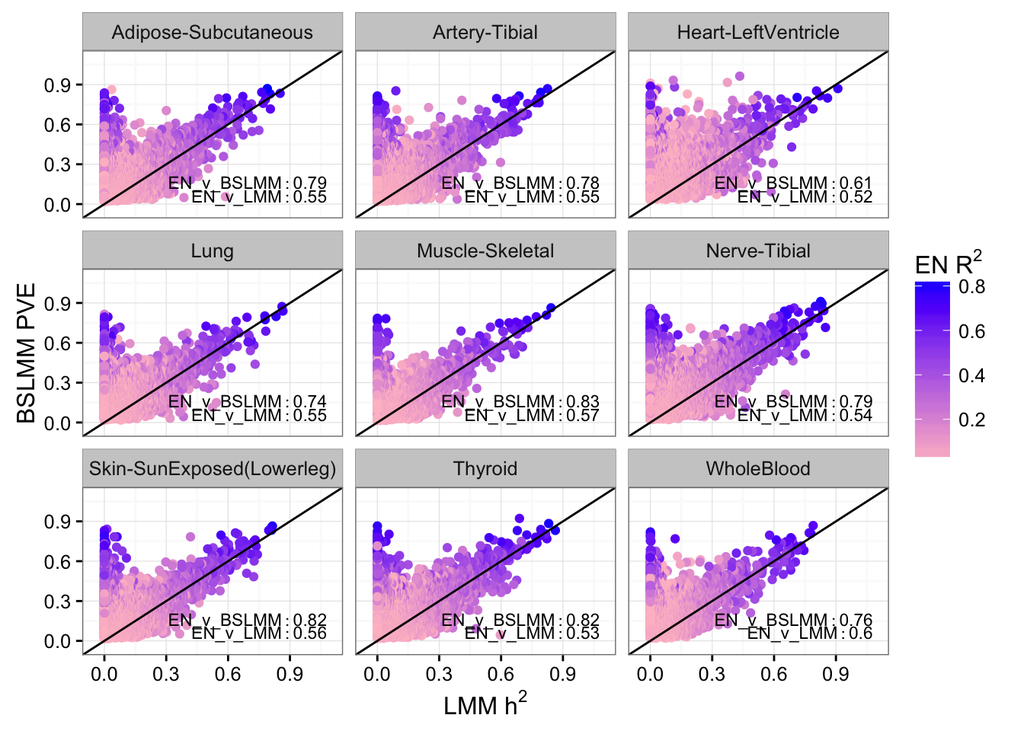

```r
p<-ggplot(tw,aes(x=h2,y=pve50,color=R2))+geom_point()+coord_cartesian(xlim=c(-0.05,1.1),ylim=c(-0.05,1.1))+xlab(expression("LMM h"^2))+ylab('BSLMM PVE')+geom_abline(intercept=0,slope=1) + scale_colour_gradient(low="pink",high="blue",name=expression("EN R"^2)) + facet_wrap(~tissue,ncol=3)+theme_bw()

ann_text <- data.frame( h2 = rep(1.08,9), pve50 = rep(0.15,9), R= rvec3[1:9], tissue = factor(tislist), ensid=rep(0.9,9),gene=rep(0.9,9))
ann_text2 <- data.frame( h2 = rep(1.08,9), pve50 = rep(0.05,9), R= rvec2[1:9], tissue = factor(tislist), ensid=rep(0.9,9),gene=rep(0.9,9))
p2<-p+geom_text(data=ann_text,aes(label=paste("EN_v_BSLMM:",R,sep=" ")),color="black",show_guide=F,parse=T,hjust=1,size=3)
p3<-p2+geom_text(data=ann_text2,aes(label=paste("EN_v_LMM:",R,sep=" ")),color="black",show_guide=F,parse=T,hjust=1,size=3)
p3
```

```r
png(filename=fig.dir %&% "Fig-GTEx_TW_PVE_v_h2.png",width=700,height=600)
p3
dev.off()
```

```r
p2<-p+geom_text(data=ann_text,aes(label=paste("EN_v_BSLMM:",R,sep=" ")),color="black",show_guide=F,parse=T,hjust=1,size=2.8)
p3<-p2+geom_text(data=ann_text2,aes(label=paste("EN_v_LMM:",R,sep=" ")),color="black",show_guide=F,parse=T,hjust=1,size=2.8)
setEPS()
postscript(file=fig.dir %&% "Fig-GTEx_TW_PVE_v_h2.eps",width=9,height=8)
p3
dev.off()
```

```r
#h2 Spearman cor table
h2d<-dplyr::select(tw,tissue,ensid,h2)
h2dat <- h2d[duplicated(h2d)==FALSE,]
h2tab<-tidyr::spread(h2dat,tissue,h2)
dim(h2tab)
```

```
## [1] 16052    10
```

```r
cor(h2tab[,-1],use='p',method='s')
```

```
##                           Adipose-Subcutaneous Artery-Tibial
## Adipose-Subcutaneous                 1.0000000     0.5596452
## Artery-Tibial                        0.5596452     1.0000000
## Heart-LeftVentricle                  0.4605584     0.4798467
## Lung                                 0.5399004     0.5120696
## Muscle-Skeletal                      0.5060992     0.5074221
## Nerve-Tibial                         0.5882399     0.5640470
## Skin-SunExposed(Lowerleg)            0.5360634     0.4976798
## Thyroid                              0.5399108     0.5405968
## WholeBlood                           0.4685527     0.4524901
##                           Heart-LeftVentricle      Lung Muscle-Skeletal
## Adipose-Subcutaneous                0.4605584 0.5399004       0.5060992
## Artery-Tibial                       0.4798467 0.5120696       0.5074221
## Heart-LeftVentricle                 1.0000000 0.4437007       0.4709172
## Lung                                0.4437007 1.0000000       0.4725523
## Muscle-Skeletal                     0.4709172 0.4725523       1.0000000
## Nerve-Tibial                        0.4578457 0.5364840       0.5103004
## Skin-SunExposed(Lowerleg)           0.4426950 0.5075104       0.4944049
## Thyroid                             0.4719082 0.5118174       0.4689525
## WholeBlood                          0.4073370 0.4847876       0.4329156
##                           Nerve-Tibial Skin-SunExposed(Lowerleg)   Thyroid
## Adipose-Subcutaneous         0.5882399                 0.5360634 0.5399108
## Artery-Tibial                0.5640470                 0.4976798 0.5405968
## Heart-LeftVentricle          0.4578457                 0.4426950 0.4719082
## Lung                         0.5364840                 0.5075104 0.5118174
## Muscle-Skeletal              0.5103004                 0.4944049 0.4689525
## Nerve-Tibial                 1.0000000                 0.5292336 0.5518363
## Skin-SunExposed(Lowerleg)    0.5292336                 1.0000000 0.5031617
## Thyroid                      0.5518363                 0.5031617 1.0000000
## WholeBlood                   0.4745710                 0.4734746 0.4643482
##                           WholeBlood
## Adipose-Subcutaneous       0.4685527
## Artery-Tibial              0.4524901
## Heart-LeftVentricle        0.4073370
## Lung                       0.4847876
## Muscle-Skeletal            0.4329156
## Nerve-Tibial               0.4745710
## Skin-SunExposed(Lowerleg)  0.4734746
## Thyroid                    0.4643482
## WholeBlood                 1.0000000
```

```r
#pve50 Spearman cor table
pve50d<-dplyr::select(tw,tissue,ensid,pve50)
pve50dat <- pve50d[duplicated(pve50d)==FALSE,]
pve50tab<-tidyr::spread(pve50dat,tissue,pve50)
dim(pve50tab)
```

```
## [1] 16052    10
```

```r
cor(pve50tab[,-1],use='p',method='s')
```

```
##                           Adipose-Subcutaneous Artery-Tibial
## Adipose-Subcutaneous                 1.0000000     0.4088979
## Artery-Tibial                        0.4088979     1.0000000
## Heart-LeftVentricle                  0.2881923     0.2935010
## Lung                                 0.3787993     0.3344581
## Muscle-Skeletal                      0.3559335     0.3274861
## Nerve-Tibial                         0.4488776     0.4170069
## Skin-SunExposed(Lowerleg)            0.4056508     0.3471089
## Thyroid                              0.3803482     0.3682595
## WholeBlood                           0.2614219     0.2360141
##                           Heart-LeftVentricle      Lung Muscle-Skeletal
## Adipose-Subcutaneous                0.2881923 0.3787993       0.3559335
## Artery-Tibial                       0.2935010 0.3344581       0.3274861
## Heart-LeftVentricle                 1.0000000 0.2655426       0.3068425
## Lung                                0.2655426 1.0000000       0.3018915
## Muscle-Skeletal                     0.3068425 0.3018915       1.0000000
## Nerve-Tibial                        0.2768368 0.3685237       0.3103238
## Skin-SunExposed(Lowerleg)           0.2651635 0.3529131       0.3036828
## Thyroid                             0.3036376 0.3496720       0.3071692
## WholeBlood                          0.2119538 0.2907312       0.2224618
##                           Nerve-Tibial Skin-SunExposed(Lowerleg)   Thyroid
## Adipose-Subcutaneous         0.4488776                 0.4056508 0.3803482
## Artery-Tibial                0.4170069                 0.3471089 0.3682595
## Heart-LeftVentricle          0.2768368                 0.2651635 0.3036376
## Lung                         0.3685237                 0.3529131 0.3496720
## Muscle-Skeletal              0.3103238                 0.3036828 0.3071692
## Nerve-Tibial                 1.0000000                 0.3831909 0.4072146
## Skin-SunExposed(Lowerleg)    0.3831909                 1.0000000 0.3496873
## Thyroid                      0.4072146                 0.3496873 1.0000000
## WholeBlood                   0.2442401                 0.2476643 0.2711773
##                           WholeBlood
## Adipose-Subcutaneous       0.2614219
## Artery-Tibial              0.2360141
## Heart-LeftVentricle        0.2119538
## Lung                       0.2907312
## Muscle-Skeletal            0.2224618
## Nerve-Tibial               0.2442401
## Skin-SunExposed(Lowerleg)  0.2476643
## Thyroid                    0.2711773
## WholeBlood                 1.0000000
```

```r
#R2 (EN alpha=1) Spearman cor table
R2d<-dplyr::select(tw,tissue,ensid,R2)
R2dat <- R2d[duplicated(h2d)==FALSE,]
R2tab<-tidyr::spread(R2dat,tissue,R2)
dim(R2tab)
```

```
## [1] 16052    10
```

```r
cor(R2tab[,-1],use='p',method='s')
```

```
##                           Adipose-Subcutaneous Artery-Tibial
## Adipose-Subcutaneous                 1.0000000     0.5557408
## Artery-Tibial                        0.5557408     1.0000000
## Heart-LeftVentricle                  0.4111432     0.4049604
## Lung                                 0.5367451     0.4841217
## Muscle-Skeletal                      0.4413277     0.4119994
## Nerve-Tibial                         0.5896143     0.5464451
## Skin-SunExposed(Lowerleg)            0.5141063     0.4559915
## Thyroid                              0.4941694     0.5008047
## WholeBlood                           0.3522066     0.3299735
##                           Heart-LeftVentricle      Lung Muscle-Skeletal
## Adipose-Subcutaneous                0.4111432 0.5367451       0.4413277
## Artery-Tibial                       0.4049604 0.4841217       0.4119994
## Heart-LeftVentricle                 1.0000000 0.4144670       0.4525899
## Lung                                0.4144670 1.0000000       0.3938673
## Muscle-Skeletal                     0.4525899 0.3938673       1.0000000
## Nerve-Tibial                        0.4008092 0.5047521       0.3956717
## Skin-SunExposed(Lowerleg)           0.3894163 0.4677300       0.3890427
## Thyroid                             0.4035934 0.5076328       0.3822063
## WholeBlood                          0.2677564 0.3823721       0.2786085
##                           Nerve-Tibial Skin-SunExposed(Lowerleg)   Thyroid
## Adipose-Subcutaneous         0.5896143                 0.5141063 0.4941694
## Artery-Tibial                0.5464451                 0.4559915 0.5008047
## Heart-LeftVentricle          0.4008092                 0.3894163 0.4035934
## Lung                         0.5047521                 0.4677300 0.5076328
## Muscle-Skeletal              0.3956717                 0.3890427 0.3822063
## Nerve-Tibial                 1.0000000                 0.4762793 0.5135142
## Skin-SunExposed(Lowerleg)    0.4762793                 1.0000000 0.4589534
## Thyroid                      0.5135142                 0.4589534 1.0000000
## WholeBlood                   0.3344977                 0.3471328 0.3509720
##                           WholeBlood
## Adipose-Subcutaneous       0.3522066
## Artery-Tibial              0.3299735
## Heart-LeftVentricle        0.2677564
## Lung                       0.3823721
## Muscle-Skeletal            0.2786085
## Nerve-Tibial               0.3344977
## Skin-SunExposed(Lowerleg)  0.3471328
## Thyroid                    0.3509720
## WholeBlood                 1.0000000
```

## Fig 5

### Calculate entropy of Pr and correlate with **cross-tissue and tissue-specific** h2

- higher entropy means more likely to be multi-tissue eQTL (expect positive cor. for entropy vs. cross-tissue h2)

Stephens lab data accessed from http://www.gtexportal.org/static/datasets/gtex_analysis_pilot_v3/multi_tissue_eqtls/Multi_tissue_eQTL_GTEx_Pilot_Phase_datasets.tar on 20150722.

From README: “We are using the eQTL posterior probabilities from the UC Multi-tissue eQTL method (doi:10.1371/journal.pgen.1003486) for each of the 9 tissues analyzed in the pilot phase (Adipose_subcutaneous, Artery_Tibal, Whole_Blood, Heart_Left_Ventricle, Lung, Muscle_Skeletal, Nerve_Tibial, Skin_Lower_Leg_Sun_Exposed, Thyroid) in the file res_final_uc_com_genes_com_snps.txt.gz. These values may be interpreted as Pr(SNP is eQTL in tissue s | data). 9875 eGenes are presented, with the”top" (most significant) SNP in each gene used."

```r
mt.dir <- "/Volumes/im-lab/nas40t2/hwheeler/cross-tissue/Multi_tissue_eQTL_GTEx_Pilot_Phase_datasets/"
h2.dir <- "/Volumes/im-lab/nas40t2/hwheeler/cross-tissue/"
bslmm.dir <- "/Volumes/im-lab/nas40t2/hwheeler/cross-tissue/BSLMM_exp/"
mt <- read.table(mt.dir %&% "res_final_uc_com_genes_com_snps.txt.gz",header=TRUE)
#remove version number in order to compare ensembl IDs
a <- substr(mt$gene,1,15)
mt <- mutate(mt,gene=a)
h2.ts <- read.table(my.dir %&% "GTEx_Tissue-Specific_local_h2.txt",header=TRUE)
#remove version number in order to compare ensembl IDs
a <- substr(h2.ts$ensid,1,15)
h2.ts <- mutate(h2.ts,gene=a)
h2.tw <- read.table(my.dir %&% "GTEx_Tissue-Wide_local_h2.txt",header=TRUE)
#remove version number in order to compare ensembl IDs
a <- substr(h2.tw$ensid,1,15)
h2.tw <- mutate(h2.tw,gene=a)

entropy <- function(pr){
  pi <- pr/sum(pr)
  pi[pi==0] <- 1e-06 ##allows log transformation
  -1*sum(pi*log(pi))
}

mtPr <- mt[,3:11]
mtS <- apply(mtPr,1,entropy) ##calc entropy for each row
summary(mtS)
norm_mtS = (mtS-min(mtS))/(max(mtS)-min(mtS)) #normalize b/t 0 and 1
geneS <- select(mt,gene) %>% mutate(entropy=norm_mtS) ##put gene and entropy together

tis <- 'CrossTissue'

h2.tis <- h2.ts %>% select(gene,one_of(tis)) ##one_of allows character vector
newdata <- inner_join(geneS,h2.tis,by='gene')
groupdata <- dplyr::mutate(newdata, group=ifelse(entropy<0.33,0,1))
groupdata <- dplyr::mutate(newdata, group=ifelse(entropy>0.67,2,groupdata$group))
colnames(groupdata)[3] <- "h2"
p <- ggplot(groupdata,aes(y=h2,x=factor(group,labels=c("0-0.33","0.33-0.67","0.67-1"))))+geom_boxplot()+ylab(expression(paste("Cross-Tissue ", "h"^{2}))) + xlab("Uniformity")
cors <- data.frame(pval=signif(kruskal.test(h2~factor(group),groupdata)$p.value, 2))
p1 <- p + geom_text(data=cors, aes(label=paste("P = ", pval, sep="")), x=-Inf, y=Inf, hjust=-0.5, vjust=2, size=5)
print(kruskal.test(h2~factor(group),groupdata))
a <- p1 + theme_bw(16) #+ coord_cartesian(ylim=c(1.75,2.25))
print(a)

tiff(filename=fig.dir %&% "Fig-CT-entropy.tiff",width=360,height=360)
a
dev.off()

png(filename=fig.dir %&% "Fig-CT-entropy.png",width=360,height=360)
a
dev.off()
```

## Fig 6

### Table of Pr vs PVE correlations

```r
pve.tw <- read.table(bslmm.dir %&% "GTEx_Tissue-Wide_local_PVE_by_BSLMM.txt",header=TRUE)
#remove version number in order to compare ensembl IDs
pve.tw <- mutate(pve.tw,gene=substr(pve.tw$gene,1,15))
mtPVE <- inner_join(mt,pve.tw,by='gene')
corMat <- round(cor(mtPVE[,3:dim(mtPVE)[2]],use="p"),3)
###Pr rows, PVE cols
mat2.tw <- corMat[1:9,11:dim(corMat)[2]]
colnames(mat2.tw)<-c('Whole: Adipose','Artery','Heart','Lung','Muscle','Nerve','Skin','Thyroid','WholeBlood')
rownames(mat2.tw)<-c('Adipose','Artery','WholeBlood','Heart','Lung','Muscle','Nerve','Skin','Thyroid')
mat2.tw <- mat2.tw[ order(row.names(mat2.tw)), ]
rownames(mat2.tw)[1] <- 'PPA: Adipose'

pve.ts <- read.table(bslmm.dir %&% "GTEx_Tissue-Specific_local_PVE_by_BSLMM.txt",header=TRUE)
#remove version number in order to compare ensembl IDs
pve.ts <- mutate(pve.ts,gene=substr(pve.ts$gene,1,15))
mtPVE <- inner_join(mt,pve.ts,by='gene')
corMat <- round(cor(mtPVE[,3:dim(mtPVE)[2]],use="p"),3)
###Pr rows, PVE cols
mat2 <- corMat[1:9,11:dim(corMat)[2]]
colnames(mat2)<-c('OTD: Adipose','Artery','Heart','Lung','Muscle','Nerve','Skin','Thyroid','WholeBlood')
rownames(mat2)<-c('Adipose','Artery','WholeBlood','Heart','Lung','Muscle','Nerve','Skin','Thyroid')
mat2 <- mat2[ order(row.names(mat2)), ]
rownames(mat2)[1] <- 'PPA: Adipose'

tiff(filename=fig.dir %&% "Fig-cor-StephensPr-v-PVE.tiff",width=960,height=480)
par(mfrow=c(1,2))
corrplot(mat2.tw,method="circle",cl.lim = c(-0.35, 0.35),is.corr = FALSE,tl.cex=1.5,cl.cex=1.2,cl.ratio = 0.4,bg='black')
corrplot(mat2,method="circle",cl.lim = c(-0.35, 0.35),is.corr = FALSE,tl.cex=1.5,cl.cex=1.2,cl.ratio = 0.4,bg='black')
dev.off()

png(filename=fig.dir %&% "Fig-cor-StephensPr-v-PVE.png",width=960,height=480)
par(mfrow=c(1,2))
corrplot(mat2.tw,method="circle",cl.lim = c(-0.35, 0.35),is.corr = FALSE,tl.cex=1.5,cl.cex=1.2,cl.ratio = 0.4,bg='black')
corrplot(mat2,method="circle",cl.lim = c(-0.35, 0.35),is.corr = FALSE,tl.cex=1.5,cl.cex=1.2,cl.ratio = 0.4,bg='black')
dev.off()
```